# Species metadata description

# Biodiversity mapping

The following pdf gives a description of the data used in the pipeline run that corresponds to the folder this document resides in. It should be used as a guide for anyone who wants to know more about the data used in the corresponding outputs (maps and datasets) and/or would like to replicate the data.

We begin with basic information about the pipeline run.

| Characteristic | Value |
| --- | --- |
| Date | 2023-12-05 |
| Taxa | amphibiansReptiles, flies, dragonflies, mammals |
| Region type | country |
| Region code | Norway |
| Total species | 5332 |
| Total datasets used | 31 |
| DOI | 10.15468/dl.z8ugm7 |

In addition to the above, data was downloaded with a maximum uncertainty regarding coordinates of 100 metres.

| taxa | species | redListedSpecies |
| --- | --- | --- |
| amphibiansReptiles | 31 | 1 |
| dragonflies | 70 | 4 |
| flies | 5081 | 8 |
| mammals | 150 | 4 |

| dsName | dataType | observations | redListedObservations |
| --- | --- | --- | --- |
| Freshwater benthic invertebrates ecological collection NTNU University Museum | PA | 5450994 | 0 |
| National insect monitoring in Norway | Counts | 379427 | 443 |
| Norwegian Species Observation Service | PO | 197497 | 3506 |
| Terrestrial and limnic invertebrates systematic collection, NTNU University Museum | PO | 32440 | 4 |
| Entomology, Oslo (O) UiO | PO | 22720 | 26 |
| Freshwater pelagic invertebrates ecological collection NTNU University Museum | PA | 12329 | 0 |
| NORSC - Sciaroidea, UiT Tromsø Museum | PO | 8551 | 44 |
| Diptera collection, Natural History Museum, University of Oslo | PO | 5236 | 8 |
| Norwegian Biodiversity Information Centre - Other datasets | PO | 5202 | 389 |
| NINA insect database | PO | 3378 | 2 |

The following gives species richness for observations across the surveyed region by taxa.

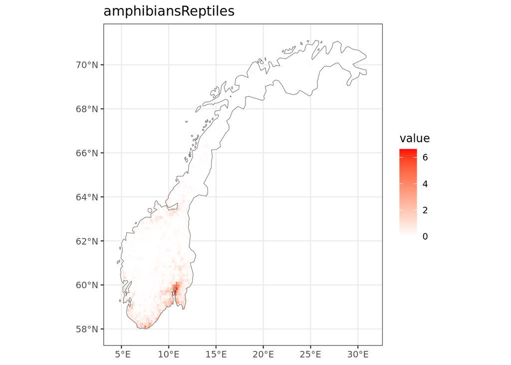

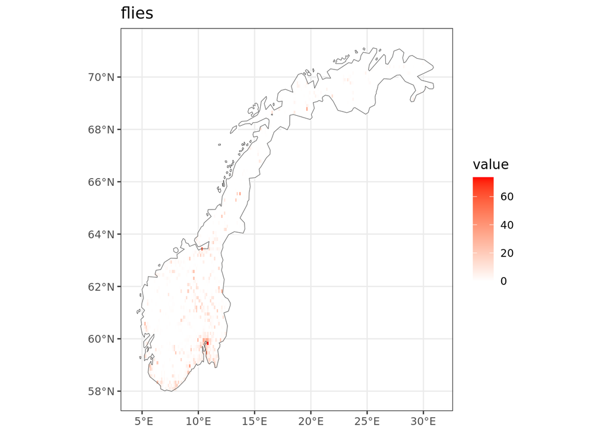

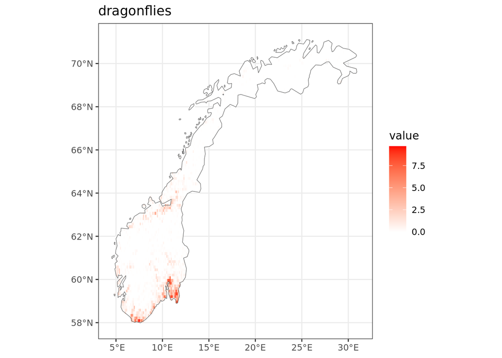

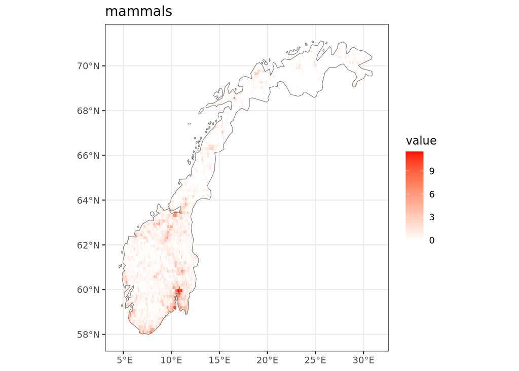

The following gives spatial density for observations across the surveyed region by taxa.

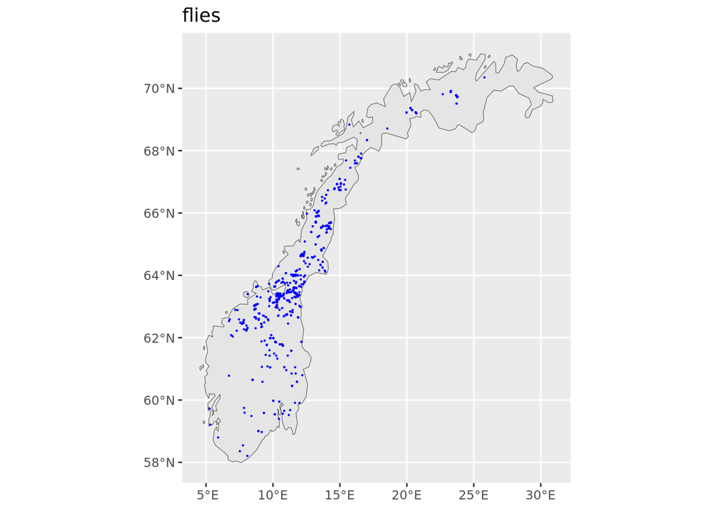

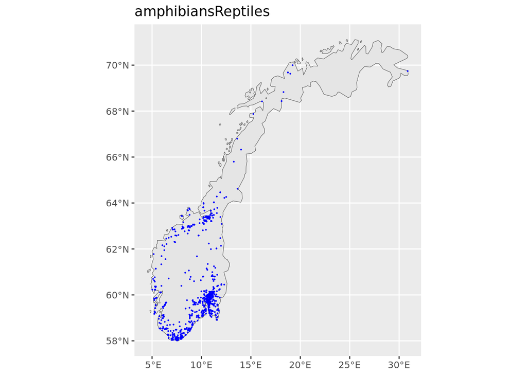

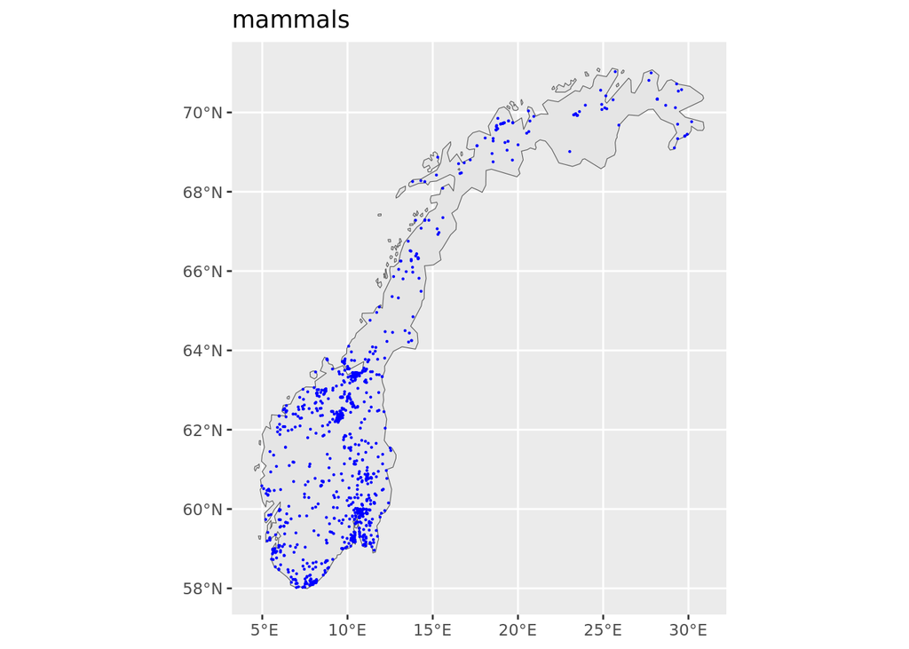

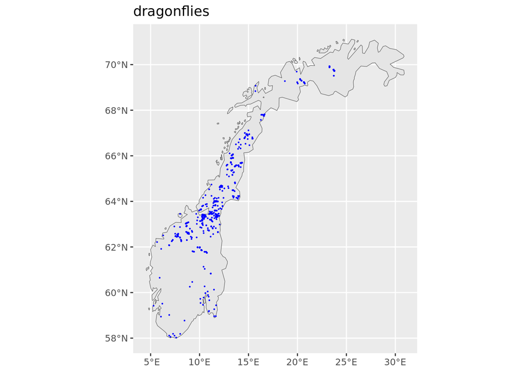

## Appendices

### Appendix 1

The tables below give further information on the observations used for our pipeline run.

Total numbers of observations used in pipeline run for each dataset by taxa.

| taxa | dsName | Observations |
| --- | --- | --- |
| amphibiansReptiles | Norwegian Species Observation Service | 24046 |
| amphibiansReptiles | Norwegian Biodiversity Information Centre - Other datasets | 3470 |
| amphibiansReptiles | Herpetile collection NTNU University Museum | 2785 |
| amphibiansReptiles | iNaturalist Research-grade Observations | 419 |
| amphibiansReptiles | Reptilia notes, NTNU University Museum | 261 |
| amphibiansReptiles | Observation.org, Nature data from around the World | 186 |
| amphibiansReptiles | Jordal | 17 |
| amphibiansReptiles | ANM Zoological vertebrate collection | 14 |
| amphibiansReptiles | naturgucker | 10 |
| amphibiansReptiles | Artportalen (Swedish Species Observation System) | 5 |
| amphibiansReptiles | Occurrence data from various smaller projects in Norway | 2 |
| amphibiansReptiles | Ecofact | 1 |
| amphibiansReptiles | Mammal collection (TSZM) The Arctic University Museum of Norway | 1 |
| dragonflies | Freshwater benthic invertebrates ecological collection NTNU University Museum | 1083429 |
| dragonflies | Norwegian Species Observation Service | 28745 |
| dragonflies | Terrestrial and limnic invertebrates systematic collection, NTNU University Museum | 1306 |
| dragonflies | National insect monitoring in Norway | 760 |
| dragonflies | Observation.org, Nature data from around the World | 520 |
| dragonflies | Entomology, Oslo (O) UiO | 467 |
| dragonflies | Collection of various insect orders, Natural History Museum, University of Oslo | 278 |
| dragonflies | iNaturalist Research-grade Observations | 263 |
| dragonflies | Artportalen (Swedish Species Observation System) | 11 |
| dragonflies | Hatikka.fi observations | 11 |
| dragonflies | naturgucker | 6 |
| dragonflies | Insect collection, UiT, University Museum (TSZ). Insect labeling project and PhD-duty-work | 5 |
| dragonflies | Jordal | 4 |
| dragonflies | Entomological collections, UiB | 3 |
| dragonflies | Arthropod collection, UiT Tromsø Museum | 2 |
| dragonflies | Entomology collection, UiT Tromsø Museum | 2 |
| flies | Freshwater benthic invertebrates ecological collection NTNU University Museum | 4367565 |
| flies | National insect monitoring in Norway | 378667 |
| flies | Norwegian Species Observation Service | 49067 |
| flies | Terrestrial and limnic invertebrates systematic collection, NTNU University Museum | 31134 |
| flies | Entomology, Oslo (O) UiO | 22253 |
| flies | Freshwater pelagic invertebrates ecological collection NTNU University Museum | 12329 |
| flies | NORSC - Sciaroidea, UiT Tromsø Museum | 8551 |
| flies | Diptera collection, Natural History Museum, University of Oslo | 5236 |
| flies | NINA insect database | 3378 |
| flies | Entomological collections, UiB | 2510 |
| flies | Insect collection, UiT, University Museum (TSZ). Insect labeling project and PhD-duty-work | 1454 |
| flies | iNaturalist Research-grade Observations | 562 |
| flies | Observation.org, Nature data from around the World | 546 |
| flies | Entomology collection, UiT Tromsø Museum | 110 |
| flies | Artportalen (Swedish Species Observation System) | 37 |
| flies | Saproxylic insects caught in window traps and hatched from polypores in small and large old forests in southern Norway | 13 |
| flies | naturgucker | 5 |
| flies | Invertebrate collections, UiB | 4 |
| mammals | Norwegian Species Observation Service | 95639 |
| mammals | Villreinobservasjoner | 2266 |
| mammals | Norwegian Biodiversity Information Centre - Other datasets | 1732 |
| mammals | Observation.org, Nature data from around the World | 1409 |
| mammals | iNaturalist Research-grade Observations | 1206 |
| mammals | Mammal collection NTNU University Museum | 1201 |
| mammals | ANM Zoological vertebrate collection | 563 |
| mammals | Mammal collection (TSZM) The Arctic University Museum of Norway | 111 |
| mammals | Artportalen (Swedish Species Observation System) | 43 |
| mammals | naturgucker | 41 |
| mammals | Jordal | 7 |
| mammals | Occurrence data from various smaller projects in Norway | 2 |

Total numbers of observations used in pipeline run for each data type by taxa.

| taxa | dataType | Observations |
| --- | --- | --- |
| amphibiansReptiles | PO | 31217 |
| dragonflies | PA | 1083429 |
| dragonflies | PO | 31623 |
| dragonflies | Counts | 760 |
| flies | PA | 4379907 |
| flies | Counts | 378667 |
| flies | PO | 124847 |
| mammals | PO | 104220 |